# MTH6139 Time Series

Coursework 1 _ 231180728

Jixiu WU

Spring term 2025

# 1. Introduction

This project shows the monthly Consumer Price Index of Transportation in U.S. City average for all urban consumers from January 1947 to February 2026. It measures how the price of transportation change over time.

The purpose of the project is to analyse the monthly Consumer Price Index time series. The objective is to identify trend and seasonal patterns, then build a time series model using Prophet.

Using Prophet is because Prophet could capture both trend and seasonality in time series data in a simple way.

# 2. Data

```
##           ds    y
## 1 1947-01-01 17.9
## 2 1947-02-01 17.9
## 3 1947-03-01 18.1
## 4 1947-04-01 18.3
## 5 1947-05-01 18.3
## 6 1947-06-01 18.4
```

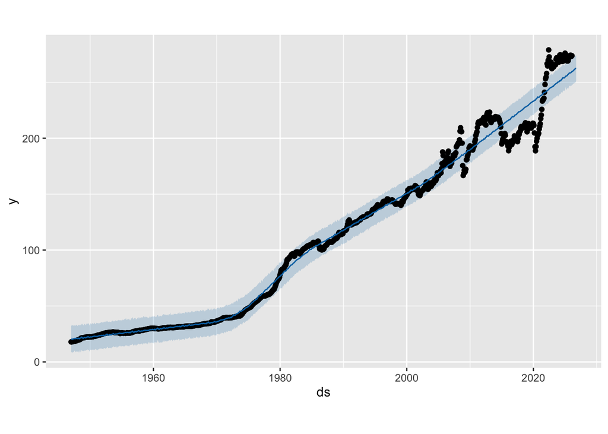

# 3.Trend

# 4.Seasonality

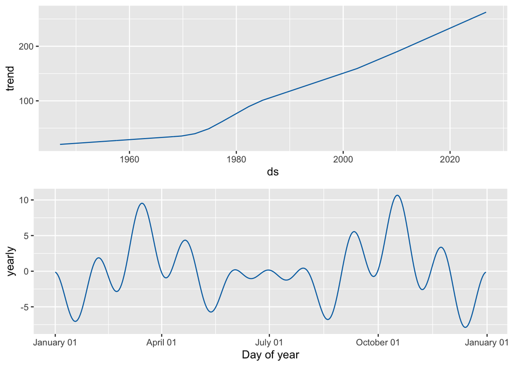

The seasonal component shows some variations within a year. There are several peaks and dips at different times of the year. However, the magnitude of changes is relatively small compared to the overall trend.

# 5.Forecasting Results

The forecasting result shows that the monthly Consumer Price Index will continue increasing in the future. This follows the strong upward trend in the data. The uncertainty intervals show some variations around predictions. Therefore, there are some uncertainty in the forecast.

# 6.Summary

ln summary, this project analyses the monthly Consumer Price Index of Transportation time series. This data shows a clear upward trend from 1947 to 2026. Seasonal fluctuations were present but minor relative to the trend. The forecast shows that prices of transportation will probably still rise in the future, ebven there might be some short-term fluctuations. However, the results shoud be treated with caution, because unexpected events could affect future changes.

# References

- RStudio reference: https://rmarkdown.rstudio.com/lesson-1.html
- Data reference: https://fred.stlouisfed.org/series/CPITRNSL